# The Temporal Dynamics of Emotional Energy

Matteo Tiratelli

19/12/2020

## An initial test and an agenda for future research

For many of the earliest sociologists, the emotional dynamics provoked by crowds and group interaction were the heart of the new discipline. Today, the most famous of these theories is Durkheim’s foundational work on *effervescence collective* – a force or energy generated by ritual interactions, which helps to unify the group and becomes invested in particular ‘sacred’ objects. These ideas have left a lasting impression on the modern sociology of emotions and, in particular, on the enormously influential work of Randall Collins (especially Collins 2004a, 2008). In Collins’s (2012) recent research on violence, he not only makes emotional energy (visceral feelings of collective identity and shared focus of attention) a central concept, but also argues that the temporal profile of emotional energy is characterised by a particular shape: explosion, plateau and slow dissipation (reproduced in Figure 1 below). His primary evidence for this is an ingenious attempt to measure the solidarity produced by conflict by counting public displays of U.S. flags in the aftermath of the September 11 attacks (Collins 2004b). This is a relatively passive form of group identification in the sense that, once the flag is up, you have to make an effort to take it down. But Collins is clear that he suspects that other forms of emotional energy will also follow this pattern of explosion, plateau and dissipation (Collins 2012: 14).

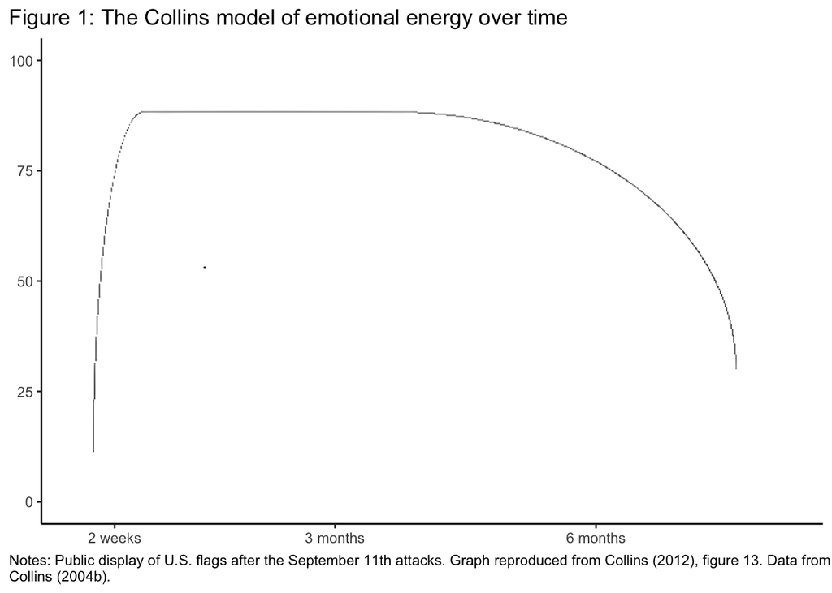

Unfortunately, there has been very little work following up on these ideas and attempting to provide other measures of emotional energy over time. The supposition that passive forms of identity display are a good proxy for emotional energy in general, or for conflict solidarity in particular, therefore remains unproven. In order to test this supposition, I compare Collins’s results to the temporal pattern of a more active form of behaviour: online searches, which can be thought of as a proxy for attention towards and emotional investment in a topic. This clearly only addresses one half of what Collins means by 'emotional energy' (shared focus of attention, rather than visceral feelings of collective identity). But attention plays a key role in his theories and he often uses a sense of '*where the action is*' as a vital indicator of the presence of emotional energy (Collins 2001).

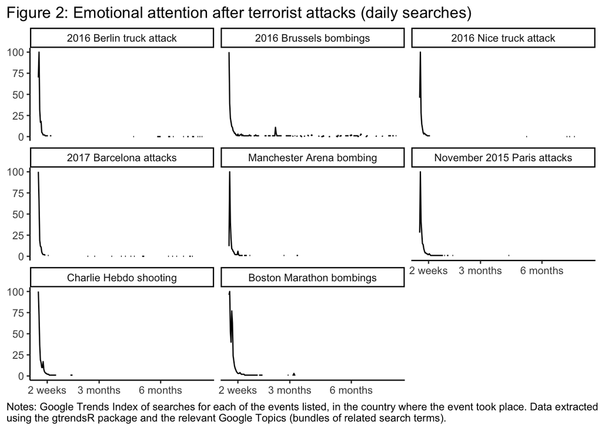

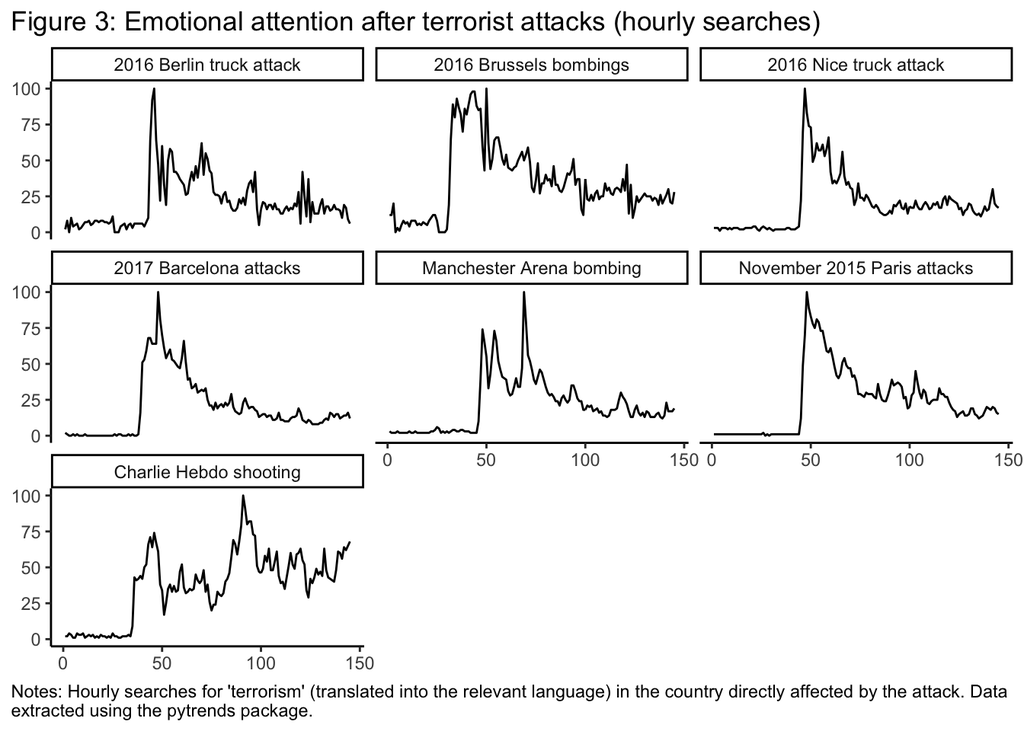

There are several ways of interpreting the stark differences between these two patterns (explosion-plateau-dissipation vs. spike-decline). At the level of theory, one could infer that the two elements of emotional energy (attention and feelings of collective identity) simply have different temporal dynamics. Empirically, the differences between these results might suggest that the September 11 attacks were relatively unusual in their ability to generate a sustained state of heightened emotional energy. Or, at the level of methodology, it could be that the two proxies (public displays of identity and private search activity) are simply measuring different things entirely.

Each of these interpretations points to the need for further research which tries to bridge the gap between theories of emotion and measurement. This is a daunting undertaking. All I can do here is suggest some initial steps. First, we need clearer, operationalisable definitions of emotional energy (a concept which has come in for its share of criticism over the years, e.g. Felson 2009). This will require distinguishing it from emotions more broadly and may include stronger differentiation between its two component parts. Second, we need more theoretical work on the link between active displays of emotional energy and its passive or latent forms. We may be able to find clues in Durkheim's work the embodiment of *effervescence collective* in objects, symbols and relationships or in Collins's idea of 'interation ritual chains' (Collins 2004a). Third, the measurement of emotions is clearly in its infancy and it may be that we have to rely on proxy measures for a long time yet. But we nevertheless should try to compare our findings for the temporal dynamics of emotional energy across a population, with other attempts to measure the time profile of emotions at the individual level (how long does grief last?). Various sources suggest themselves for the former: longitudinal data (if it is collected regularly enough), repeated cross-sectional data (if appropriate survey questions can be found), and the use of Twitter/Facebook profile picture frames (a phenomenon which closely matches Collins's original data). But whatever sources we use, we will need to join the dots between these sociological investigations and work in the (neuro-)psychology of emotions.

As Collins's work on violence indicates, the study of emotions has huge potential to illuminate many other areas of social life. The next phase is to begin the rigorous quantitative investigation of those ideas, not as a replacement for theoretical and qualitative work but, hopefully, as a valuable supplement.

All data and code are available from https://github.com/MatteoTiratelli/TimeDynamicsEmotionalEnergy.

### Bibliography

- Biggs, Michael. ‘Strikes as Forest Fires: Chicago and Paris in the Late Nineteenth Century’. American Journal of Sociology 110, no. 6 (2005): 1684–1714.
- Collins, Randall. 'Social Movements and the Focus ofEmotional Attention' in Passionate Politics. University of Chicago Press, 2001.
- Collins, Randall. Interaction Ritual Chains. Princeton University Press, 2004a.
- Collins, Randall.‘Rituals of Solidarity and Security in the Wake of Terrorist Attack’. Sociological Theory 22, no. 1 (2004b): 53–87.
- Collins, Randall. Violence: A Micro-Sociological Theory. Princeton University Press, 2008.
- Collins, Randall. ‘C-Escalation and D-Escalation: A Theory of the Time-Dynamics of Conflict’. American Sociological Review 77, no. 1 (2012): 1–20.
- Felson, Richard 'Is violence natural, unnatural, or rational?'. The British Journal of Sociology 60, no. 3 (2009): 577-585.